# 220606_trial_averaged_stimulus_response_dfs

### get average response dataframe, averaging over all changes presentations in 10 minute epochs in the session

```python
df = stimulus_response_df.copy()
```

```python
# check that 'epoch' column is in the dataframe so it can be used as a condition to group by
df.keys()
```

```
Index(['stimulus_presentations_id', 'cell_specimen_id', 'trace',
       'trace_timestamps', 'mean_response', 'baseline_response',
       'p_value_gray_screen', 'ophys_frame_rate', 'data_type', 'event_type',
       'interpolate', 'output_sampling_rate', 'response_window_duration',
       'start_time', 'stop_time', 'duration', 'image_name', 'image_index',
       'is_change', 'omitted', 'start_frame', 'end_frame', 'image_set',
       'licks', 'mean_running_speed', 'reward_rate_trials', 'epoch',
       'trials_id', 'change_time', 'go', 'catch', 'aborted', 'auto_rewarded',
       'hit', 'miss', 'false_alarm', 'correct_reject', 'response_time',
       'response_latency', 'reward_time', 'reward_volume', 'rewarded',
       'reward_rate_per_second', 'reward_rate', 'engaged', 'engagement_state',
       'time_from_last_change', 'pre_change', 'pre_omitted', 'post_omitted',
       'licked', 'lick_on_next_flash', 'frame_rate', 'exclude_invalid_rois'],
      dtype='object')
```

```python
import visual_behavior.ophys.response_analysis.utilities as ut
```

```python
# get params for mean df creation from stimulus_response_df
if 'response_window_duration' in df.keys():
    response_window_duration = df.response_window_duration.values[0]
output_sampling_rate = df.frame_rate.unique()[0]
timestamps = df.trace_timestamps.values[0]
window_around_timepoint_seconds = [timestamps[0], timestamps[-1]]

# set conditions to average over
conditions = ['cell_specimen_id', 'epoch']
# use VBA get_mean_df function to average over trials defined by `conditions`
# must use same time_window and frame rate as was used to create the stim_response_df
mdf = ut.get_mean_df(df, conditions=conditions, frame_rate=output_sampling_rate,
                     time_window=time_window, response_window_duration=response_window_duration)
# get rid of last epoch which doesnt have 10 full minutes in it
epochs = np.sort(mdf.epoch.unique())
mdf = mdf[mdf.epoch<epochs[-1]]
```

```python
mdf.head(3)
```

|  | cell_specimen_id | epoch | mean_response | sem_response | mean_trace | sem_trace | trace_timestamps | mean_responses | mean_baseline | sem_baseline | response_window_duration | fano_factor | peak_response | time_to_peak | p_value | sd_over_baseline | fraction_significant_p_value_gray_screen | reliability | correlation_values |
| --- | --- | --- | --- | --- | --- | --- | --- | --- | --- | --- | --- | --- | --- | --- | --- | --- | --- | --- | --- |
| 0 | 1157152838 | 0 | 0.046280 | 0.008041 | [-0.012199797613191779, -0.012247351090620482,... | [0.015650344384645958, 0.014990897708778022, 0... | [-3.0, -2.966666666666668, -2.9333333333333327... | [0.060822094999087514, 0.0717100039089949, 0.1... | -0.009901 | 0.010590 | 0.5 | 1.737402 | 0.076979 | 0.266667 | 6.191129e-09 | 3.883407 | 0.440000 | 0.030802 | [0.18707681181671063, 0.7166727421288949, 0.28... |
| 1 | 1157152838 | 1 | 0.050308 | 0.006432 | [0.011839090833916007, 0.012669363836058095, 0... | [0.012479521220842157, 0.01250013591873294, 0.... | [-3.0, -2.966666666666668, -2.9333333333333336... | [0.1159659258776442, -0.01590334638979228, 0.0... | 0.016427 | 0.007654 | 0.5 | 1.468822 | 0.089437 | 0.233333 | 1.551863e-06 | 9.941990 | 0.424242 | 0.098395 | [-0.5203967795194145, 0.8731867866305196, -0.5... |
| 2 | 1157152838 | 2 | 0.063059 | 0.006859 | [0.01616523979730032, 0.015763250202315136, 0.... | [0.013673149659509562, 0.013116437982355919, 0... | [-3.0, -2.966666666666668, -2.933333333333334,... | [0.04478745017078148, 0.02911787742961676, 0.0... | 0.005728 | 0.006828 | 0.5 | 1.287000 | 0.102716 | 0.233333 | 7.256622e-08 | 8.613148 | 0.514286 | 0.131187 | [-0.8626962860970627, -0.6452970913391443, 0.5... |

### function to plot the average +/- sem trace for one cell

```python
import visual_behavior.visualization.utils as utils
```

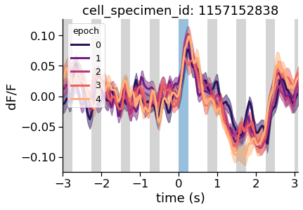

```python
cell_specimen_id = mdf.cell_specimen_id.unique()[0]
epochs = mdf.epoch.unique()
colors = sns.color_palette('magma', len(epochs))
fig, ax = plt.subplots()
for i,epoch in enumerate(epochs):
    cell_data = mdf[(mdf.cell_specimen_id==cell_specimen_id)&(mdf.epoch==epoch)]
    ax = utils.plot_mean_trace_from_mean_df(cell_data, frame_rate=output_sampling_rate, color=colors[i],
                                            legend_label=epoch, xlims=time_window, ax=ax)
    ax = utils.plot_flashes_on_trace(ax, timestamps=cell_data.trace_timestamps.values[0], change=True)
ax.legend(fontsize='x-small', title='epoch', title_fontsize='x-small', loc='upper left')
ax.set_title('cell_specimen_id: '+str(cell_specimen_id))
```

### Aggregate trial averaged responses for all session for one container

```python
# get some container for special mouse
mouse_data = experiments_table[experiments_table.mouse_id==mouse_id]
container_id = mouse_data.ophys_container_id.unique()[0]
experiment_ids = mouse_data[mouse_data.ophys_container_id==container_id].index.values
print(len(experiment_ids))
```

```
16
```

Note: this takes a while

```python
# params for stim_response_df
data_type = 'dff'
event_type = 'changes'
time_window = [-2, 2.1]
interpolate = True
output_sampling_rate = 30

# conditions to average trials over
conditions = ['cell_specimen_id', 'image_name']

# loop through experients and aggregated trial averaged dfs
big_mdf = pd.DataFrame()
for experiment_id in experiment_ids:
    try: # not all experiments load so need to to try except
        print('expt_id:', experiment_id, ',', np.where(experiment_ids==experiment_id)[0][0], 'out of', len(experiment_ids))
        # get dataset
        dataset = loading.get_ophys_dataset(experiment_id)
        # get stimulus_response_df
        df = loading.get_stimulus_response_df(dataset, data_type=data_type, event_type=event_type, time_window=time_window,
                                              interpolate=interpolate, output_sampling_rate=output_sampling_rate)
        # get params for mean df creation from stimulus_response_df
        if 'response_window_duration' in df.keys():
            response_window_duration = df.response_window_duration.values[0]
        output_sampling_rate = df.frame_rate.unique()[0]
        timestamps = df.trace_timestamps.values[0]
        window_around_timepoint_seconds = [timestamps[0], timestamps[-1]]
        # get trial averaged response for conditions
        mdf = ut.get_mean_df(df, conditions=conditions, frame_rate=output_sampling_rate,
                             time_window=time_window,
                             response_window_duration=response_window_duration)
        # add experiment ID to be able to distinguish different sessions
        mdf['ophys_experiment_id'] = experiment_id
        # aggregate
        big_mdf = pd.concat([big_mdf, mdf])
    except Exception as e:
        print(e)
        print('problem for', experiment_id)
```

```
expt_id: 1153662776 , 0 out of 16
loading from lims, exclude_invalid_rois = True
```

[output not shown]

```
dff_frames (len=10000) is not equal to number of split timestamps (len=39108).
problem for 1153662776
expt_id: 1154288470 , 1 out of 16
loading from lims, exclude_invalid_rois = True
```

[output not shown]

```
dff_frames (len=10000) is not equal to number of split timestamps (len=39171).
problem for 1154288470
expt_id: 1156776076 , 2 out of 16
loading from lims, exclude_invalid_rois = True
```

[output not shown]

```
generating response df
```

```
expt_id: 1155524645 , 3 out of 16
loading from lims, exclude_invalid_rois = True
```

[output not shown]

```
generating response df
```

```
expt_id: 1155760211 , 4 out of 16
loading from lims, exclude_invalid_rois = True
```

[output not shown]

```
dff_frames (len=10000) is not equal to number of split timestamps (len=48431).
problem for 1155760211
expt_id: 1156990807 , 5 out of 16
loading from lims, exclude_invalid_rois = True
```

[output not shown]

```
generating response df
```

```
expt_id: 1157244788 , 6 out of 16
loading from lims, exclude_invalid_rois = True
```

[output not shown]

```
generating response df
expt_id: 1153099564 , 7 out of 16
loading from lims, exclude_invalid_rois = True
```

[output not shown]

```
dff_frames (len=10000) is not equal to number of split timestamps (len=10154).
problem for 1153099564
expt_id: 1153920574 , 8 out of 16
loading from lims, exclude_invalid_rois = True
```

[output not shown]

```
generating response df
```

```
expt_id: 1154572294 , 9 out of 16
loading from lims, exclude_invalid_rois = True
```

[output not shown]

```
generating response df
```

```
expt_id: 1154369482 , 10 out of 16
loading from lims, exclude_invalid_rois = True
```

[output not shown]

```
dff_frames (len=10000) is not equal to number of split timestamps (len=39203).
problem for 1154369482
expt_id: 1155282299 , 11 out of 16
loading from lims, exclude_invalid_rois = True
```

[output not shown]

```
dff_frames (len=10000) is not equal to number of split timestamps (len=39171).
problem for 1155282299
expt_id: 1155949174 , 12 out of 16
loading from lims, exclude_invalid_rois = True
```

[output not shown]

```
generating response df
```

```
expt_id: 1156751809 , 13 out of 16
loading from lims, exclude_invalid_rois = True
```

[output not shown]

```
generating response df
```

```
expt_id: 1157477422 , 14 out of 16
loading from lims, exclude_invalid_rois = True
```

[output not shown]

```
generating response df
```

```
expt_id: 1157708787 , 15 out of 16
loading from lims, exclude_invalid_rois = True
```

[output not shown]

```
generating response df
```

```python
big_mdf.keys()
```

```
Index(['cell_specimen_id', 'image_name', 'mean_response', 'sem_response',
       'mean_trace', 'sem_trace', 'trace_timestamps', 'mean_responses',
       'mean_baseline', 'sem_baseline', 'response_window_duration',
       'pref_stim', 'fano_factor', 'peak_response', 'time_to_peak', 'p_value',
       'sd_over_baseline', 'fraction_significant_p_value_gray_screen',
       'reliability', 'correlation_values', 'ophys_experiment_id'],
      dtype='object')
```

```python
len(big_mdf)
```

```
608
```

```python
big_mdf = big_mdf.merge(experiments_table, on='ophys_experiment_id')
len(big_mdf)
```

```
608
```

### plot population average response for each image_name within each session_type

```python
def condense_session_types(df):
    df = df.copy()
    df = df.reset_index()
    for row in range(len(df)):
        session_type = df.iloc[row].session_type
        # all of Training 4 and 5 are basically the same
        if session_type in ['TRAINING_4_images_A_training', 'TRAINING_5_images_A_epilogue', 'TRAINING_5_images_A_handoff_ready']:
            df.at[row, 'session_type'] = 'TRAINING_4_images_A'
        # for the first training session with images, remove the '10uL_reward bit'
        elif session_type == 'TRAINING_3_images_A_10uL_reward':
            df.at[row, 'session_type'] = 'TRAINING_3_images_A'
        # otherwise, keep the same name
        else:
            pass
    return df
```

```python
big_mdf = condense_session_types(big_mdf)
```

```python
import visual_behavior.visualization.ophys.platform_paper_figures as ppf
```

```
array([<matplotlib.axes._subplots.AxesSubplot object at 0x0000022C0AEF7E48>,
      dtype=object)
```

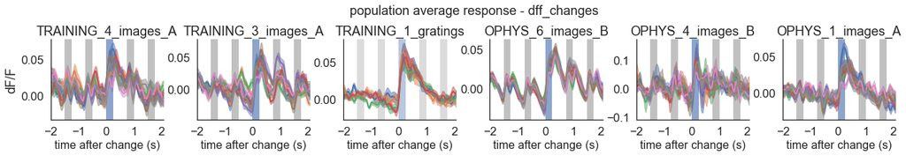

```python
axes_column = 'session_type'
hue_column = 'image_name'
palette = sns.color_palette()

ppf.plot_population_averages_for_conditions(big_mdf, data_type, event_type, axes_column, hue_column, palette=palette,
                                        suptitle=None, horizontal=True, save_dir=None, folder=None)
```

### Aggregate trial averaged responses accross all sessions and all imaging planes for a given mouse

```python
from visual_behavior.ophys.io.create_multi_session_df import get_multi_session_df
```

This function will run the steps above iteratively for all sessions for the provided mouse_id and project code:

```
* load dataset for each experiment
* generate stimulus_response_df to get stimulus aligned traces
* compute mean response dataframe averaged over the provided set of conditions
* concatenate with all other sessions
```

NOTE: this takes tens of minutes

There is code to do this on the cluster in `visual_behavior_analysis.scripts.run_create_multi_session_df.py`

```python
project_code = 'LearningmFISHTask1A'
conditions = ['cell_specimen_id', 'image_name']
data_type = 'dff'
event_type = 'changes'

multi_session_df = get_multi_session_df(project_code, mouse_id, conditions, data_type, event_type,
                         time_window=[-3, 3.1], interpolate=True, output_sampling_rate=30, response_window_duration=0.5)
```

[output not shown]

```
get_pref_stim True
getting up-to-date experiment_table from lims
including failed data
excluding Ai94 data
616 expts in experiments table
creating multi session mean df for mean_response_df_dff_changes_LearningmFISHTask1A_603892_image_name.h5
1153662776
loading from lims, exclude_invalid_rois = True
```

[output not shown]

```
dff_frames (len=10000) is not equal to number of split timestamps (len=39108).
problem for 1153662776
1153662777
loading from lims, exclude_invalid_rois = True
```

[output not shown]

```
dff_frames (len=10000) is not equal to number of split timestamps (len=39108).
problem for 1153662777
1153662768
loading from lims, exclude_invalid_rois = True
```

[output not shown]

```
file exists:
loading response df from file for 1153662768 dff changes
get_mean_df() got an unexpected keyword argument 'window_around_timepoint_seconds'
problem for 1153662768
1153662770
loading from lims, exclude_invalid_rois = True
```

[output not shown]

```
dff_frames (len=10000) is not equal to number of split timestamps (len=39108).
problem for 1153662770
1153662771
loading from lims, exclude_invalid_rois = True
```

[output not shown]

```
file exists:
loading response df from file for 1153662771 dff changes
get_mean_df() got an unexpected keyword argument 'window_around_timepoint_seconds'
problem for 1153662771
1153662774
loading from lims, exclude_invalid_rois = True
```

[output not shown]

```
file exists:
loading response df from file for 1153662774 dff changes
get_mean_df() got an unexpected keyword argument 'window_around_timepoint_seconds'
problem for 1153662774
1153662779
loading from lims, exclude_invalid_rois = True
```

[output not shown]

```
dff_frames (len=10000) is not equal to number of split timestamps (len=39108).
problem for 1153662779
1153662773
loading from lims, exclude_invalid_rois = True
```

[output not shown]

```
dff_frames (len=10000) is not equal to number of split timestamps (len=39108).
problem for 1153662773
1154288458
loading from lims, exclude_invalid_rois = True
```

[output not shown]

```
dff_frames (len=10000) is not equal to number of split timestamps (len=39171).
problem for 1154288458
1154288461
loading from lims, exclude_invalid_rois = True
```

[output not shown]

```
dff_frames (len=10000) is not equal to number of split timestamps (len=39171).
problem for 1154288461
1154288463
loading from lims, exclude_invalid_rois = True
```

[output not shown]

```
dff_frames (len=10000) is not equal to number of split timestamps (len=39171).
problem for 1154288463
1154288465
loading from lims, exclude_invalid_rois = True
```

[output not shown]

```
Unable to open file (unable to open file: name = '\\allen\programs\mindscope\production\learning\prod0\specimen_1142290487\ophys_session_1154000392\ophys_experiment_1154288465\demix\1154288465_demixed_traces.h5', errno = 2, error message = 'No such file or directory', flags = 0, o_flags = 0)
problem for 1154288465
1154288467
loading from lims, exclude_invalid_rois = True
```

[output not shown]

```
dff_frames (len=10000) is not equal to number of split timestamps (len=39171).
problem for 1154288467
1154288470
loading from lims, exclude_invalid_rois = True
```

[output not shown]

```
dff_frames (len=10000) is not equal to number of split timestamps (len=39171).
problem for 1154288470
1154288472
loading from lims, exclude_invalid_rois = True
```

[output not shown]

```
Unable to open file (unable to open file: name = '\\allen\programs\mindscope\production\learning\prod0\specimen_1142290487\ophys_session_1154000392\ophys_experiment_1154288472\demix\1154288472_demixed_traces.h5', errno = 2, error message = 'No such file or directory', flags = 0, o_flags = 0)
problem for 1154288472
1154288475
loading from lims, exclude_invalid_rois = True
```

[output not shown]

```
Unable to open file (unable to open file: name = '\\allen\programs\mindscope\production\learning\prod0\specimen_1142290487\ophys_session_1154000392\ophys_experiment_1154288475\demix\1154288475_demixed_traces.h5', errno = 2, error message = 'No such file or directory', flags = 0, o_flags = 0)
problem for 1154288475
1156776068
loading from lims, exclude_invalid_rois = True
```

[output not shown]

```
file exists:
loading response df from file for 1156776068 dff changes
get_mean_df() got an unexpected keyword argument 'window_around_timepoint_seconds'
problem for 1156776068
1156776070
loading from lims, exclude_invalid_rois = True
```

[output not shown]

```
file exists:
loading response df from file for 1156776070 dff changes
get_mean_df() got an unexpected keyword argument 'window_around_timepoint_seconds'
problem for 1156776070
1156776071
loading from lims, exclude_invalid_rois = True
```

[output not shown]

```
file exists:
loading response df from file for 1156776071 dff changes
get_mean_df() got an unexpected keyword argument 'window_around_timepoint_seconds'
problem for 1156776071
1156776073
loading from lims, exclude_invalid_rois = True
```

[output not shown]

```
file exists:
loading response df from file for 1156776073 dff changes
get_mean_df() got an unexpected keyword argument 'window_around_timepoint_seconds'
problem for 1156776073
1156776074
loading from lims, exclude_invalid_rois = True
```

[output not shown]

```
file exists:
loading response df from file for 1156776074 dff changes
get_mean_df() got an unexpected keyword argument 'window_around_timepoint_seconds'
problem for 1156776074
1156776076
loading from lims, exclude_invalid_rois = True
```

[output not shown]

[output not shown]

[output cut: 51 more lines]

[output not shown]